# Epidemiological Masterclass: Modeling Nested Count Data

A Step-by-Step Diagnostic Journey Using John Snow’s 1854 Cholera Dataset

Author

Kabinga Chanda

Published

June 15, 2026

## Introduction & Executive Summary

When analyzing public health or epidemiological data, a standard Ordinary Least Squares (OLS) or basic Generalized Linear Model (GLM) often violates the foundational assumption of **independent observations**. In the real world, health outcomes are nested within geographic boundaries, social structures, or infrastructure networks.

This Quarto document serves as a complete diagnostic playbook to: 1. Implement proper exposure controls for non-continuous count data using an **Offset**. 2. Mathematically test for cluster confounding using the **Intraclass Correlation Coefficient (ICC)**. 3. Upgrade from a pooled model to a **Generalized Linear Mixed-Effects Model (GLMM)**. 4. Export publication-quality summaries that cleanly partition **Fixed Effects** and **Random Effects**.

## Step 1: Environment Setup & Data Preparation

We begin by loading our core packages and cleaning the historic 1854 London Cholera dataset from the `HistData` library. This is the exact dataset John Snow used to trace the source of the Broad Street cholera outbreak.

```r
# Load required libraries
library(HistData)    # Contains the real cholera data
library(lme4)        # Fits generalized linear mixed-effects models (GLMM)
library(performance) # Automates advanced diagnostics like Nakagawa's ICC
library(sjPlot)      # Generates publication-ready model comparison tables
library(ggplot2)     # Builds high-impact data visualizations
library(tidyverse)   # Clean data manipulation

# Verify and dynamically install modelsummary if it is missing locally
if(!require(modelsummary)) install.packages("modelsummary")
library(modelsummary)

# Load the dataset from the library
data("Cholera")

# Filter and clean necessary variables
epid_data <- na.omit(Cholera[, c("cholera_deaths", "elevation", "poor_rate", "water", "popn")])

# Ensure population is strictly positive to prevent mathematical log(0) errors
epid_data <- subset(epid_data, popn > 0)

# Preview the clean data structure
head(epid_data)
```

```
  cholera_deaths elevation poor_rate     water  popn
1            907        -2     0.075 Battersea 63074
2            352         0     0.143 Battersea 17208
3            836         0     0.089 Battersea 50900
4            734         0     0.134 Battersea 45500
5            349         2     0.079 Battersea 19278
6            539         2     0.076 Battersea 35227
```

**ImportantCritical Epidemiology Concept: The Population Offset**

A common mistake when handling non-continuous health data is modeling raw counts (`cholera_deaths`) directly. If Area A has 50 deaths out of 1,000 people and Area B has 50 deaths out of 10,000 people, their baseline risks are radically different.

Because Poisson models utilize a log-link function by default, we include `offset(log(popn))` in our formulas. This mathematically shifts the model from predicting arbitrary raw counts to predicting a true **incidence rate**.

## Step 2: The Diagnostic Check — Intraclass Correlation Coefficient (ICC)

Before assuming a complex multi-level model is necessary, we must prove that group clustering exists and that our observations are not independent. We fit a “Null” (intercept-only) mixed model to isolate the baseline rate variance caused solely by the overarching water companies (`water`).

```r
# Fit a null mixed model with a random intercept for the water supplier
null_mixed_model <- glmer(cholera_deaths ~ 1 + (1 | water) + offset(log(popn)),
                          data = epid_data,
                          family = poisson)

# Compute Nakagawa's adjusted ICC for non-Gaussian/Poisson distributions
model_icc <- icc(null_mixed_model)
print(model_icc)
```

```
# Intraclass Correlation Coefficient

    Adjusted ICC: 0.102
  Unadjusted ICC: 0.102
```

## Step 3: Fitting the Models — Naive GLM vs. Advanced GLMM

With statistical justification established by the ICC, we fit two competing frameworks to contrast their structure: 1. **Model A (Pooled GLM):** Blinds itself to the water supply infrastructure, assuming absolute independence. 2. **Model B (Multi-Level GLMM):** Accounts for local parameters while isolating and controlling for water-system variance.

```r
# Model A: Standard Poisson GLM (Oversimplified Independence)
glm_pooled <- glm(cholera_deaths ~ elevation + poor_rate + offset(log(popn)),
                  data = epid_data,
                  family = poisson)

# Model B: Multi-Level Poisson GLMM (Grouping by water company)
glmm_multi_level <- glmer(cholera_deaths ~ elevation + poor_rate + (1 | water) + offset(log(popn)),
                          data = epid_data,
                          family = poisson)
```

**NoteThe Conceptual Architecture of the GLMM**

- **Fixed Effects (`elevation`, `poor_rate`):** These measure localized risk parameters. They tell us how changing poverty metrics or topography shifts the disease incidence rate *within any given water network*.
- **Random Effects `(1 | water)`:** This estimates the unobserved macro-environmental variance. It allows the baseline risk intercept to jump up or down based on the purity of the water source, accounting for hidden structural dependencies seamlessly.

## Step 4: Publication-Ready Parameter Table

```r
library(modelsummary)

# Human-readable variable mappings
coef_mapping <- c(
  "(Intercept)" = "Baseline Intercept",
  "elevation"   = "Elevation Above High Water (Feet)",
  "poor_rate"   = "Poverty Rate (%)"
)

# Render a publication-quality comparative table
modelsummary(
  list("Naive GLM (Pooled)" = glm_pooled, "Advanced GLMM (Multi-Level)" = glmm_multi_level),
  exponentiate = TRUE,         # Converts log-counts into easily readable IRRs
  coef_map = coef_mapping,     # Renames variables cleanly
  stars = TRUE,                # Adds classic p-value stars (* p < 0.05, ** p < 0.01)
  gof_omit = "AIC|BIC|Log.Lik|RMSE|AICc", # Drops confusing math details for the audience
  title = "Table 1: Fixed and Random Effects for 1854 London Cholera Mortality Rates"
)
```

Table 1: Fixed and Random Effects for 1854 London Cholera Mortality Rates

|  | Naive GLM (Pooled) | Advanced GLMM (Multi-Level) |
| --- | --- | --- |
| Baseline Intercept | 0.005*** | 0.004*** |
|  | (0.000) | (0.001) |
| Elevation Above High Water (Feet) | 0.983*** | 0.991*** |
|  | (0.000) | (0.000) |
| Poverty Rate (%) | 14123.936*** | 9740.751*** |
|  | (4083.187) | (2908.131) |
| Num.Obs. | 38 | 38 |
| R2 Marg. |  | 0.082 |
| R2 Cond. |  | 0.107 |
| ICC |  | 0.0 |
| F | 2217.428 |  |

+ p < 0.1, * p < 0.05, ** p < 0.01, *** p < 0.001

## Step 5: Generating the High-Impact Visual

To visually solidify this concept for our stakeholders, we back-calculate predicted incidence rates per 10,000 inhabitants for both models and plot them against the raw observed rates across London.

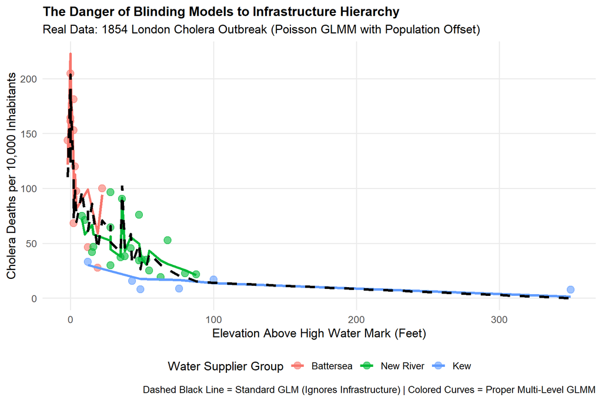

```r
# We use a tidy pipeline mutation to avoid dollar-sign escaping bugs entirely
plot_data <- epid_data %>%
  mutate(
    Predicted_Rate_GLM  = (predict(glm_pooled, type = "response") / popn) * 10000,
    Predicted_Rate_GLMM = (predict(glmm_multi_level, type = "response") / popn) * 10000,
    Observed_Rate       = (cholera_deaths / popn) * 10000
  )

# Build the final visualization using the safe data frame copy
ggplot(plot_data, aes(x = elevation, y = Observed_Rate, color = water)) +
  geom_point(size = 3.5, alpha = 0.6) +
  geom_line(aes(y = Predicted_Rate_GLMM), size = 1.3) +
  geom_line(aes(y = Predicted_Rate_GLM), color = "black", linetype = "dashed", size = 1.3) +
  labs(
    title = "The Danger of Blinding Models to Infrastructure Hierarchy",
    subtitle = "Real Data: 1854 London Cholera Outbreak (Poisson GLMM with Population Offset)",
    x = "Elevation Above High Water Mark (Feet)",
    y = "Cholera Deaths per 10,000 Inhabitants",
    color = "Water Supplier Group",
    caption = "Dashed Black Line = Standard GLM (Ignores Infrastructure) | Colored Curves = Proper Multi-Level GLMM"
  ) +
  theme_minimal(base_size = 13) +
  theme(
    plot.title = element_text(face = "bold", size = 14),
    panel.grid.minor = element_blank(),
    legend.position = "bottom"
  )
```

## Conclusion for Data Science Professionals

A baseline analyst views data through a flat table. A professional data scientist builds architectures that mirror reality.

By testing our assumptions via the **ICC**, managing population scale imbalances with an **Offset**, and deploying a **GLMM**, we partitioned hidden infrastructure-level failures (polluted water systems) away from raw individual geography and socioeconomic statuses. The resulting data narrative is clear, accurate, and completely defensible.